# Iris for Botantists

10th January 2022

## Brief

- Botanists require you to help them design an algorithm to identify flower types from 4 key measurements.
- The data is stored in iris.csv and is on your loop page.
- Give some univariate statistics to describe the data.
- What should you do with the missing data? Correlations
- Can you come up with a rules based algorithm to help the botanist? Field
- Teams of 2 people Send me by email a 7-8 page ppt slide show presentation. It should contain your assumptions, analysis and conclusions. Try and get to the point quickly and only display the relevant information. I am looking for people to make an attempt at the analysis and marks will be awarded for effort and analytical thought. Don’t be afraid to have a go and demonstrate whatever knowledge you currently have. Projects can be completed in groups of a maximum of 3.

https://www.jstor.org/stable/2394164?seq=1#metadata_info_tab_contents http://www.dicook.org/files/jsm19/slides#45 https://davetang.org/muse/2013/03/12/building-a-classification-tree-in-r/

## Explortatry Analysis

```r
read.csv("https://gist.githubusercontent.com/curran/a08a1080b88344b0c8a7/raw/0e7a9b0a5d22642a06d3d5b9bcbad9890c8ee534/iris.csv") -> iris

summary(iris)
```

```
##   sepal_length    sepal_width     petal_length    petal_width
##  Min.   :4.300   Min.   :2.000   Min.   :1.000   Min.   :0.100
##  1st Qu.:5.100   1st Qu.:2.800   1st Qu.:1.600   1st Qu.:0.300
##  Median :5.800   Median :3.000   Median :4.350   Median :1.300
##  Mean   :5.843   Mean   :3.054   Mean   :3.759   Mean   :1.199
##  3rd Qu.:6.400   3rd Qu.:3.300   3rd Qu.:5.100   3rd Qu.:1.800
##  Max.   :7.900   Max.   :4.400   Max.   :6.900   Max.   :2.500
##    species
##  Length:150
##  Class :character
##  Mode  :character
##
##
##
```

```r
library(purrr)
iris %>% split(.$species) %>% map(summary)
```

```
## $setosa
##   sepal_length    sepal_width     petal_length    petal_width
##  Min.   :4.300   Min.   :2.300   Min.   :1.000   Min.   :0.100
##  1st Qu.:4.800   1st Qu.:3.125   1st Qu.:1.400   1st Qu.:0.200
##  Median :5.000   Median :3.400   Median :1.500   Median :0.200
##  Mean   :5.006   Mean   :3.418   Mean   :1.464   Mean   :0.244
##  3rd Qu.:5.200   3rd Qu.:3.675   3rd Qu.:1.575   3rd Qu.:0.300
##  Max.   :5.800   Max.   :4.400   Max.   :1.900   Max.   :0.600
##    species
##  Length:50
##  Class :character
##  Mode  :character
##
##
##
##
## $versicolor
##   sepal_length    sepal_width     petal_length   petal_width
##  Min.   :4.900   Min.   :2.000   Min.   :3.00   Min.   :1.000
##  1st Qu.:5.600   1st Qu.:2.525   1st Qu.:4.00   1st Qu.:1.200
##  Median :5.900   Median :2.800   Median :4.35   Median :1.300
##  Mean   :5.936   Mean   :2.770   Mean   :4.26   Mean   :1.326
##  3rd Qu.:6.300   3rd Qu.:3.000   3rd Qu.:4.60   3rd Qu.:1.500
##  Max.   :7.000   Max.   :3.400   Max.   :5.10   Max.   :1.800
##    species
##  Length:50
##  Class :character
##  Mode  :character
##
##
##
##
## $virginica
##   sepal_length    sepal_width     petal_length    petal_width
##  Min.   :4.900   Min.   :2.200   Min.   :4.500   Min.   :1.400
##  1st Qu.:6.225   1st Qu.:2.800   1st Qu.:5.100   1st Qu.:1.800
##  Median :6.500   Median :3.000   Median :5.550   Median :2.000
##  Mean   :6.588   Mean   :2.974   Mean   :5.552   Mean   :2.026
##  3rd Qu.:6.900   3rd Qu.:3.175   3rd Qu.:5.875   3rd Qu.:2.300
##  Max.   :7.900   Max.   :3.800   Max.   :6.900   Max.   :2.500
##    species
##  Length:50
##  Class :character
##  Mode  :character
##
##
##
```

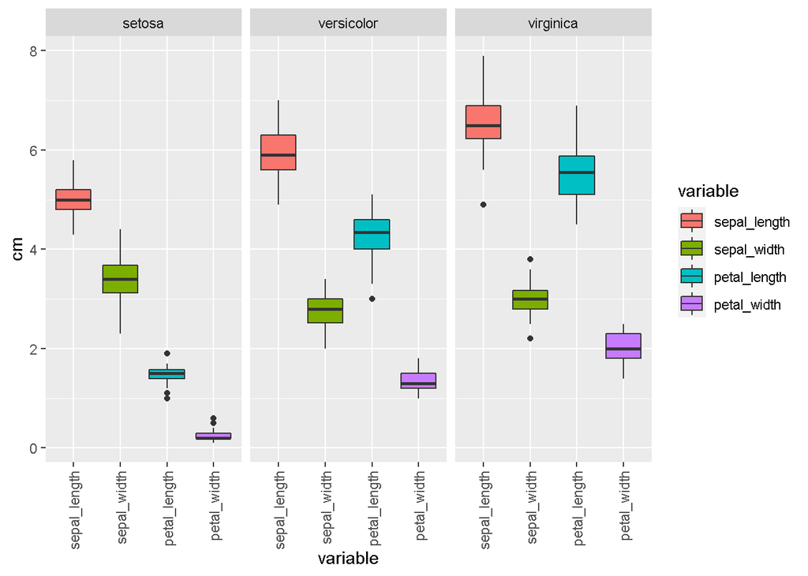

```r
iris %>% mutate(id = 1:n()) -> iris
iris2 <- melt(iris, id.vars =  c("id", "species"))
iris2 %>% rename(cm = value) -> iris2


ggplot(iris2, aes(x = variable, y = cm, fill = variable)) +
  geom_boxplot() +
  facet_wrap(~species) +
  theme(axis.text.x = element_text(angle = 90, vjust = 0.5, hjust=1))
```

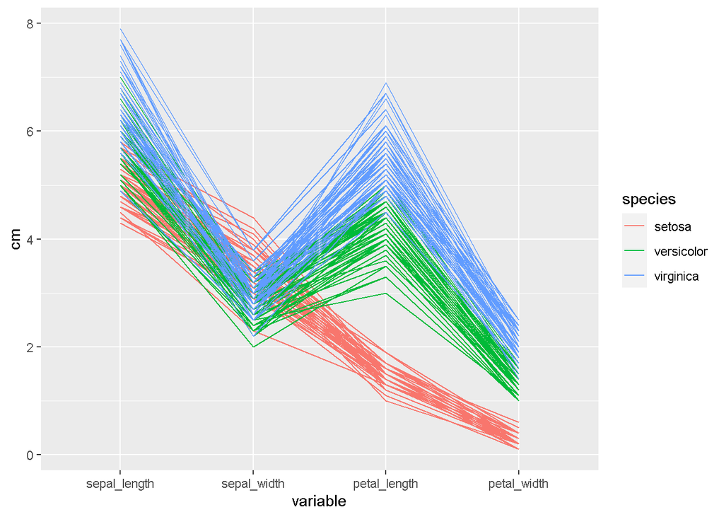

```r
ggplot(iris2, aes(x = variable, y = cm, group = id, color = species)) +
  geom_line() #+
```

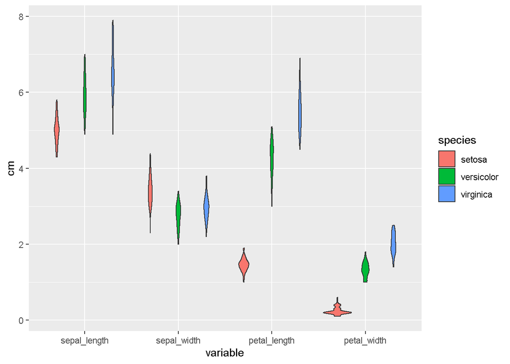

```r
ggplot(iris2, aes(x = variable, y = cm, fill = species)) +
#geom_boxplot()
geom_violin()
```

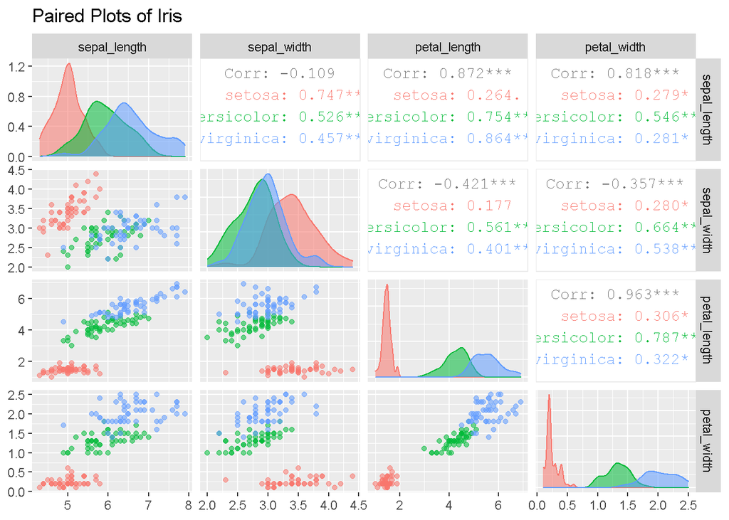

```r
library(ggplot2)
library(GGally)
        ggpairs(iris,
            columns = c(1:4),
            title="Paired Plots of Iris ",
            upper = list( combo = "facethist"),
            lower = list(combo =  'dot_no_facet',   alpha=0.2), #regrees
            diag = list(discrete = "barDiag", continuous="densityDiag"),
            mapping=ggplot2::aes(colour = species, fill=species, alpha=0.1))
```

Take a closer look at sepal length, petal length and petal width.

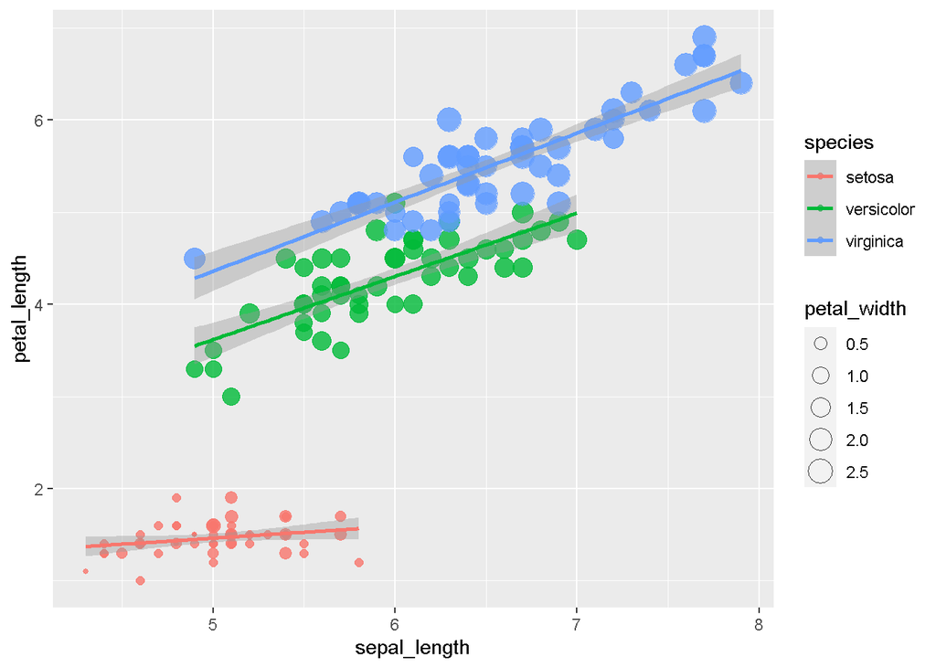

```r
ggplot(data=iris, aes(x=sepal_length, y=petal_length, color=species)) + geom_point(aes(size = petal_width, fill = species), alpha = 0.8, shape = 21) + geom_smooth(method="lm")
```

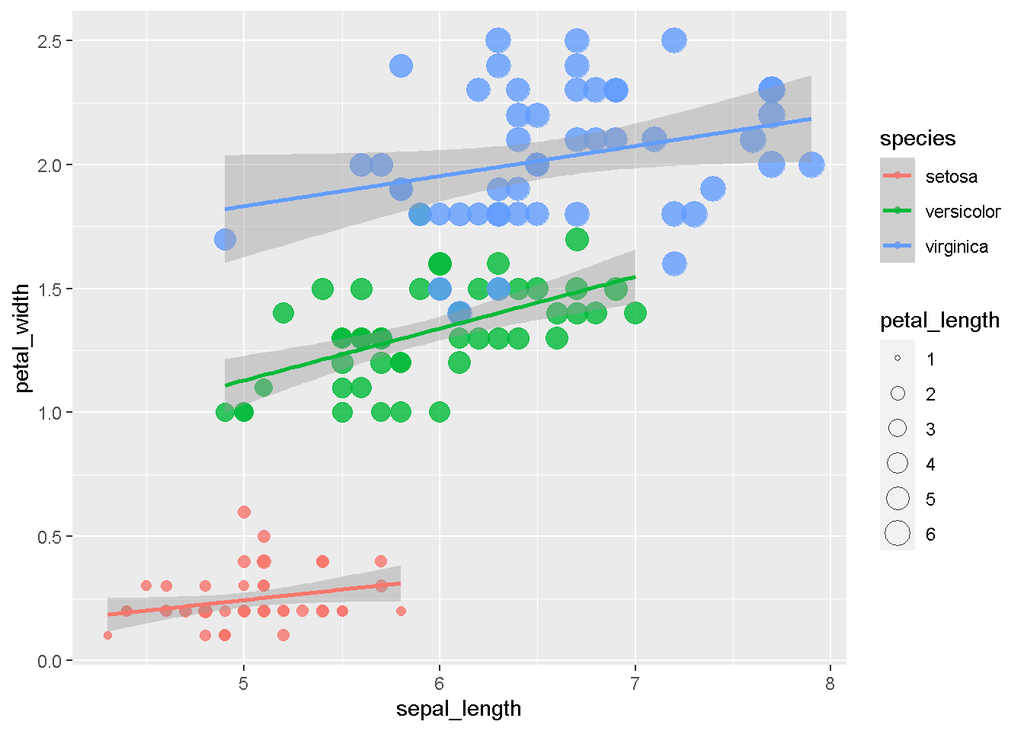

```r
ggplot(data=iris, aes(x=sepal_length, y=petal_width, color=species)) + geom_point(aes(size = petal_length, fill = species), alpha = 0.8, shape = 21) + geom_smooth(method="lm")
```

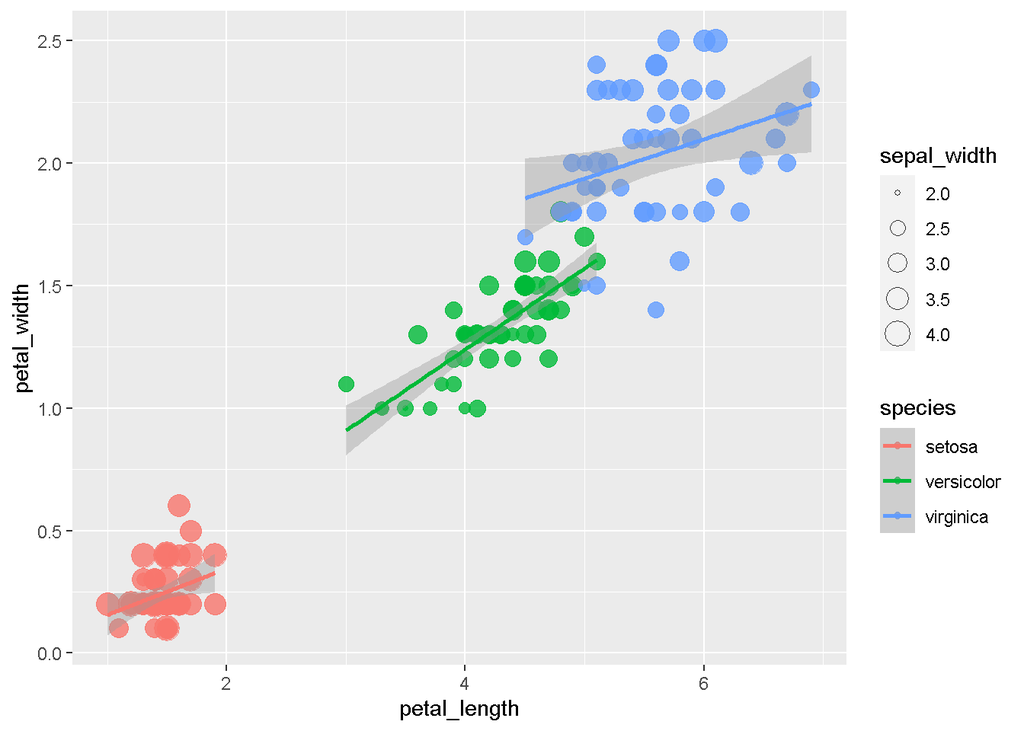

```r
ggplot(data=iris, aes(x=petal_length, y=petal_width, color=species)) + geom_point(aes(size = sepal_width, fill = species), alpha = 0.8, shape = 21) + geom_smooth(method="lm")
```

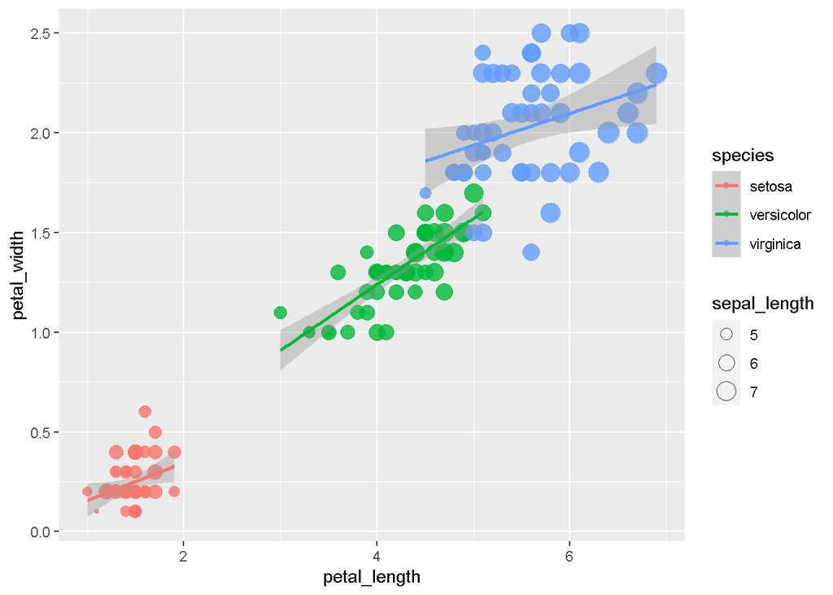

```r
ggplot(data=iris, aes(x=petal_length, y=petal_width, color=species)) + geom_point(aes(size = sepal_length, fill = species), alpha = 0.8, shape = 21) + geom_smooth(method="lm")
```

In three dimensions

```r
colors <- c("red", "green", "blue")
iris$color <- colors[ as.numeric( as.factor(iris$species) ) ]

# Plot
plot3d(
  x=iris$petal_length, y=iris$petal_width, z=iris$sepal_length,
  col = iris$color,
  type = 's',
  radius = .1,
  xlab="Sepal Length", ylab="Sepal Width", zlab="Petal Length")

# To display in an R Markdown document:
# rglwidget()

# To save to a file:
rglwidget()
```

[interactive chart not shown]

# Determine difference

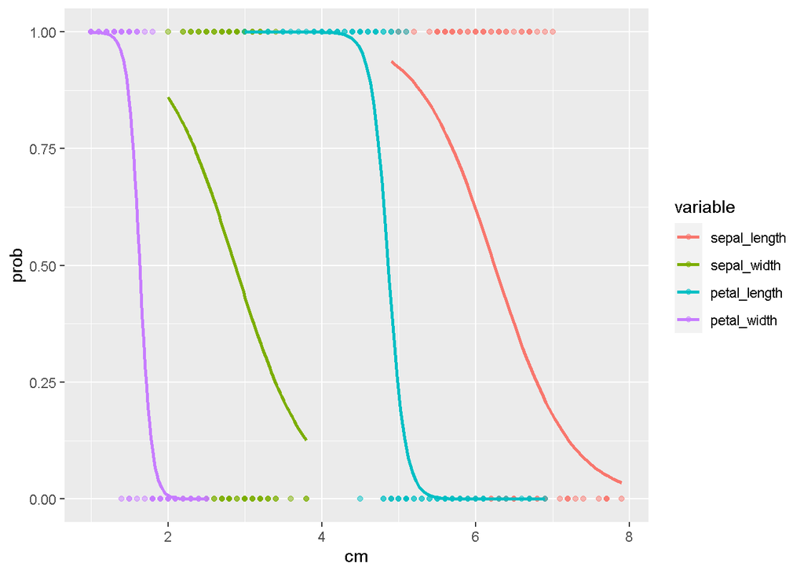

```r
# model_lm = lm(as.factor(species) ~ petal_width, data = iris3)
# plot(as.factor(species) ~ petal_width, data = iris3)
# abline(model_lm)
#
# fit <- glm(as.factor(species) ~ petal_width , data = iris3, family = binomial)


iris2 %>% filter(species != 'setosa') %>%
    mutate(prob = ifelse(species == "versicolor", 1, 0)) %>%
#ggplot( aes(x=petal_width, y=prob)) +
  ggplot( aes(x=cm, y=prob, group = variable, fill = variable, color = variable)) +

  geom_point(alpha=.5) +
  stat_smooth(method="glm", se= F,
              method.args = list(family=binomial))
```